# Citi Bike: Usage patterns + insurer decision assets

This notebook is built to work with the repo Make targets (e.g.make report-both YEARS="YYYY YYYY..." MONTHS="1 2 .. 12") It **always prefers the current run** (your `summaries/<RUN_TAG>/` folder) when you pass `YEARS/MONTHS`, so the report reflects exactly what you ingested.

## How to run (recommended)

From the repo root:

```
make all-both YEARS="YYYY YYYY..." MONTHS="1 2 .. 12"

The Makefile sets environment variables (e.g. `CITIBIKE_PARQUET_DIR`, `CITIBIKE_YEARS`, `CITIBIKE_MONTHS`) which this notebook reads.
```

```python
# --- Setup (STRICT + explicit risk variants): repo paths, run dirs, safe CSV loads ---

from __future__ import annotations

from pathlib import Path
import os
import re
import pandas as pd
import matplotlib.pyplot as plt

# Optional display in notebooks
try:
    from IPython.display import display, Markdown
except Exception:
    display = print
    Markdown = lambda x: x

# nbconvert-friendly
try:
    get_ipython().run_line_magic("matplotlib", "inline")
except Exception:
    pass
plt.ioff()

def find_repo_root(start: Path) -> Path:
    start = start.resolve()
    for p in [start, *start.parents]:
        if (p / "Makefile").exists():
            return p
    raise FileNotFoundError(
        "Could not find repo root (Makefile) by walking up from:\n"
        f"  CWD={Path.cwd().resolve()}"
    )

def _parse_int_list(val: str | None):
    if val is None:
        return None
    s = str(val).strip()
    if not s:
        return None
    parts = re.split(r"[,\s]+", s)
    out = []
    for p in parts:
        if not p:
            continue
        try:
            out.append(int(p))
        except Exception:
            pass
    return out or None

def read_csv_strict(path: Path) -> pd.DataFrame:
    if not path.exists():
        raise FileNotFoundError(f"Missing required CSV: {path}")
    return pd.read_csv(path)

def read_csv_optional(path: Path) -> pd.DataFrame | None:
    return pd.read_csv(path) if path.exists() else None

REPO_ROOT = find_repo_root(Path.cwd())
SUMMARIES_ROOT = REPO_ROOT / "summaries"

PARQUET_DIR_ENV = (os.environ.get("CITIBIKE_PARQUET_DIR") or "").strip()
RUN_DIR_ENV     = (os.environ.get("CITIBIKE_RUN_DIR") or "").strip()
MODE_ENV        = (os.environ.get("CITIBIKE_MODE") or os.environ.get("MODE") or "").strip().lower()

YEARS_FILTER  = _parse_int_list(os.environ.get("CITIBIKE_YEARS")  or os.environ.get("YEARS"))
MONTHS_FILTER = _parse_int_list(os.environ.get("CITIBIKE_MONTHS") or os.environ.get("MONTHS"))

PARQUET_DIR = Path(PARQUET_DIR_ENV) if PARQUET_DIR_ENV else Path()

if RUN_DIR_ENV:
    RUN_DIR = Path(RUN_DIR_ENV)
else:
    run_tag = PARQUET_DIR.name if str(PARQUET_DIR).strip() else ""
    RUN_DIR = (SUMMARIES_ROOT / run_tag) if run_tag else Path()

# Resolve relative paths against repo root
if str(RUN_DIR).strip() and (not RUN_DIR.is_absolute()):
    RUN_DIR = (REPO_ROOT / RUN_DIR).resolve()
if str(PARQUET_DIR).strip() and (not PARQUET_DIR.is_absolute()):
    PARQUET_DIR = (REPO_ROOT / PARQUET_DIR).resolve()

# Strict folder checks
if not SUMMARIES_ROOT.exists():
    raise FileNotFoundError(f"Expected summaries/ at: {SUMMARIES_ROOT} (run make summarize first)")

if not RUN_DIR.exists():
    raise FileNotFoundError(f"RUN_DIR not found: {RUN_DIR} (run make summarize first)")

if str(PARQUET_DIR).strip() and (not PARQUET_DIR.exists()):
    raise FileNotFoundError(f"PARQUET_DIR not found: {PARQUET_DIR} (run make ingest first)")

# Required run CSVs
REQUIRED_RUN_FILES = [
    "citibike_trips_by_year.csv",
    "citibike_trips_by_month.csv",
    "citibike_trips_by_dow.csv",
    "citibike_trips_by_hour.csv",
]
missing = [f for f in REQUIRED_RUN_FILES if not (RUN_DIR / f).exists()]
if missing:
    raise FileNotFoundError(
        f"Missing required summary CSVs in:\n  {RUN_DIR}\nMissing: {missing}\n"
        "Run: make summarize-only (or make summarize / make all)."
    )

print("REPO_ROOT:", REPO_ROOT)
print("RUN_DIR:", RUN_DIR)
print("PARQUET_DIR:", PARQUET_DIR if str(PARQUET_DIR).strip() else "(not set)")
print("MODE (env):", MODE_ENV or "(not set)")
print("YEARS_FILTER:", YEARS_FILTER, "MONTHS_FILTER:", MONTHS_FILTER)

# Figures folder
FIG_DIR = REPO_ROOT / "reports" / RUN_DIR.name / "figures"
FIG_DIR.mkdir(parents=True, exist_ok=True)
print("FIG_DIR:", FIG_DIR)

def savefig(filename: str):
    out = FIG_DIR / filename
    plt.savefig(out, dpi=200, bbox_inches="tight")
    print("Saved:", out)

# Load per-run summaries
df_year  = read_csv_strict(RUN_DIR / "citibike_trips_by_year.csv")
df_month = read_csv_strict(RUN_DIR / "citibike_trips_by_month.csv")
df_dow   = read_csv_strict(RUN_DIR / "citibike_trips_by_dow.csv")
df_hour  = read_csv_strict(RUN_DIR / "citibike_trips_by_hour.csv")

# Optional per-run outputs
df_station = read_csv_optional(RUN_DIR / "citibike_station_exposure.csv")

# Risk variants (overall + new per-year/per-month if present)
df_risk_overall = read_csv_optional(RUN_DIR / "station_risk_exposure_plus_crashproximity.csv")
df_risk_year    = read_csv_optional(RUN_DIR / "station_risk_exposure_plus_crashproximity_by_year.csv")
df_risk_ym      = read_csv_optional(RUN_DIR / "station_risk_exposure_plus_crashproximity_by_year_month.csv")

# Backward compat: keep df_risk pointing to "best available"
df_risk = df_risk_year if df_risk_year is not None else df_risk_overall

# Mode detection
mode = (
    str(df_year["mode"].iloc[0]).lower()
    if ("mode" in df_year.columns and len(df_year))
    else (MODE_ENV or "unknown")
)
print("Detected mode:", mode)

# Apply optional filters defensively
def _filter_year_month(df: pd.DataFrame) -> pd.DataFrame:
    out = df.copy()
    if YEARS_FILTER is not None and "year" in out.columns:
        out["year"] = pd.to_numeric(out["year"], errors="coerce")
        out = out[out["year"].isin(YEARS_FILTER)]
    if MONTHS_FILTER is not None and "month" in out.columns:
        out["month"] = pd.to_numeric(out["month"], errors="coerce")
        out = out[out["month"].isin(MONTHS_FILTER)]
    return out

df_year  = _filter_year_month(df_year)
df_month = _filter_year_month(df_month)
df_dow   = _filter_year_month(df_dow)
df_hour  = _filter_year_month(df_hour)

# Helpful run label
run_label = RUN_DIR.name

print("\nRisk inputs found:")
print(" - df_risk_overall:", "YES" if df_risk_overall is not None else "NO")
print(" - df_risk_year   :", "YES" if df_risk_year is not None else "NO")
print(" - df_risk_ym     :", "YES" if df_risk_ym is not None else "NO")
print("Using df_risk = ", "df_risk_year" if df_risk is df_risk_year else ("df_risk_overall" if df_risk is df_risk_overall else "None"))
```

```
REPO_ROOT: /home/hamzeh-khanpour/Desktop/CITIBIK-main
RUN_DIR: /home/hamzeh-khanpour/Desktop/CITIBIK-main/summaries/y2019_2020_2023_2025_m1_2_3_4_5_6_7_8_9_10_11_12_modejc
PARQUET_DIR: /home/hamzeh-khanpour/Desktop/CITIBIK-main/data/processed/citibike_parquet/y2019_2020_2023_2025_m1_2_3_4_5_6_7_8_9_10_11_12_modejc
MODE (env): jc
YEARS_FILTER: [2019, 2020, 2023, 2025] MONTHS_FILTER: [1, 2, 3, 4, 5, 6, 7, 8, 9, 10, 11, 12]
FIG_DIR: /home/hamzeh-khanpour/Desktop/CITIBIK-main/reports/y2019_2020_2023_2025_m1_2_3_4_5_6_7_8_9_10_11_12_modejc/figures
Detected mode: jc

Risk inputs found:
 - df_risk_overall: YES
 - df_risk_year   : YES
 - df_risk_ym     : YES
Using df_risk =  df_risk_year
```

## Executive summary (optional)

If you generated `summary_highlights.md` for this run, we show it here.

```python
# --- Quick text highlights from summarize script (if present) ---
from pathlib import Path

# Prefer the variable if it exists, else derive from RUN_DIR (which setup should define)
hp = None
if "highlights_path" in globals():
    try:
        hp = highlights_path
    except Exception:
        hp = None

if hp is None:
    if "RUN_DIR" in globals():
        hp = Path(RUN_DIR) / "summary_highlights.md"
    else:
        # Last resort: try repo-relative "summaries/latest"
        hp = Path("summaries/latest/summary_highlights.md").resolve()

if hp.exists():
    txt = hp.read_text(encoding="utf-8", errors="ignore")
    try:
        display(Markdown(txt))
    except Exception:
        print(txt)
else:
    print("No summary_highlights.md found at:", hp)
```

Summary highlights

- Mode: **jc**

Top 5 years by trips

- 2025: 994941

- 2023: 983526

- 2019: 404895

- 2020: 323249

Top 10 year-months by trips

- 2025-09: 115120

- 2023-08: 111469

- 2025-08: 107647

- 2025-07: 106944

- 2023-07: 105977

- 2025-10: 103141

- 2023-10: 96975

- 2025-06: 96437

- 2023-06: 96434

- 2023-05: 95486

Top 5 days-of-week by trips

- dow=4: 410039

- dow=2: 408838

- dow=3: 405113

- dow=1: 402481

- dow=5: 376172

Top 5 hours by trips

- hour=17: 267000

- hour=18: 266153

- hour=8: 198776

- hour=19: 194604

- hour=16: 189828

## 1) Yearly usage (comparison across years)

|  | mode | year | trips |
| --- | --- | --- | --- |
| 0 | jc | 2019 | 404895 |
| 1 | jc | 2020 | 323249 |
| 2 | jc | 2023 | 983526 |
| 3 | jc | 2025 | 994941 |

```
Saved: /home/hamzeh-khanpour/Desktop/CITIBIK-main/reports/y2019_2020_2023_2025_m1_2_3_4_5_6_7_8_9_10_11_12_modejc/figures/01_trips_by_year.png
```

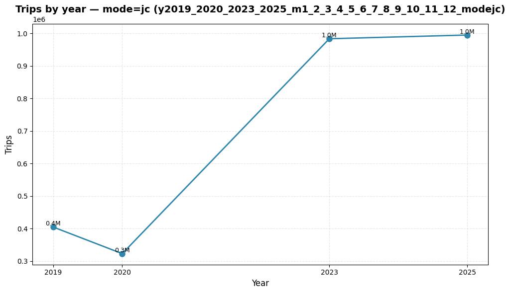

```python
# --- Trips by year (THIS RUN) ---
g = df_year.copy()

if "year" in g.columns:
    # Clean and prepare data
    g["year"] = pd.to_numeric(g["year"], errors="coerce")
    g = g.dropna(subset=["year"]).sort_values("year").reset_index(drop=True)

display(g)

# Plot
plt.figure(figsize=(10, 6))

if "year" in g.columns and "trips" in g.columns:
    # Extract values as plain lists (no pandas magic)
    years = [int(y) for y in g["year"]]
    trips = [int(t) for t in g["trips"]]

    # Plot with explicit year labels
    plt.plot(years, trips, marker="o", linewidth=2, markersize=8, color='#2E86AB')
    plt.xticks(years, [str(y) for y in years])  # Explicit year labels
    plt.grid(True, alpha=0.3, linestyle='--')

    # Add value labels on points
    for year, trip in zip(years, trips):
        plt.text(year, trip, f'{trip/1e6:.1f}M',
                ha='center', va='bottom', fontsize=9)

plt.title(f"Trips by year — mode={mode} ({run_label})", fontsize=14, fontweight='bold')
plt.xlabel("Year", fontsize=12)
plt.ylabel("Trips", fontsize=12)
plt.tight_layout()

savefig("01_trips_by_year.png")
plt.show()
```

## 2) Month patterns (comparison)

|  | mode | year | month | trips | days_in_month | trips_per_day |
| --- | --- | --- | --- | --- | --- | --- |
| 0 | jc | 2019 | 1 | 19676 | 31 | 634.709677 |
| 1 | jc | 2019 | 2 | 18564 | 28 | 663.000000 |
| 2 | jc | 2019 | 3 | 23604 | 31 | 761.419355 |
| 3 | jc | 2019 | 4 | 33050 | 30 | 1101.666667 |
| 4 | jc | 2019 | 5 | 36123 | 31 | 1165.258065 |
| 5 | jc | 2019 | 6 | 39422 | 30 | 1314.066667 |
| 6 | jc | 2019 | 7 | 43741 | 31 | 1411.000000 |
| 7 | jc | 2019 | 8 | 48706 | 31 | 1571.161290 |
| 8 | jc | 2019 | 9 | 49240 | 30 | 1641.333333 |
| 9 | jc | 2019 | 10 | 42247 | 31 | 1362.806452 |
| 10 | jc | 2019 | 11 | 30794 | 30 | 1026.466667 |
| 11 | jc | 2019 | 12 | 19728 | 31 | 636.387097 |
| 12 | jc | 2020 | 1 | 26020 | 31 | 839.354839 |
| 13 | jc | 2020 | 2 | 22961 | 29 | 791.758621 |
| 14 | jc | 2020 | 3 | 17716 | 31 | 571.483871 |
| 15 | jc | 2020 | 4 | 9267 | 30 | 308.900000 |
| 16 | jc | 2020 | 5 | 25064 | 31 | 808.516129 |
| 17 | jc | 2020 | 6 | 36906 | 30 | 1230.200000 |
| 18 | jc | 2020 | 7 | 38656 | 31 | 1246.967742 |
| 19 | jc | 2020 | 8 | 43252 | 31 | 1395.225806 |
| 20 | jc | 2020 | 9 | 40368 | 30 | 1345.600000 |
| 21 | jc | 2020 | 10 | 30078 | 31 | 970.258065 |
| 22 | jc | 2020 | 11 | 21269 | 30 | 708.966667 |
| 23 | jc | 2020 | 12 | 11692 | 31 | 377.161290 |
| 24 | jc | 2023 | 1 | 55811 | 31 | 1800.354839 |
| 25 | jc | 2023 | 2 | 51001 | 28 | 1821.464286 |
| 26 | jc | 2023 | 3 | 62802 | 31 | 2025.870968 |
| 27 | jc | 2023 | 4 | 80379 | 30 | 2679.300000 |
| 28 | jc | 2023 | 5 | 95486 | 31 | 3080.193548 |
| 29 | jc | 2023 | 6 | 96434 | 30 | 3214.466667 |
| 30 | jc | 2023 | 7 | 105977 | 31 | 3418.612903 |
| 31 | jc | 2023 | 8 | 111469 | 31 | 3595.774194 |
| 32 | jc | 2023 | 9 | 93670 | 30 | 3122.333333 |
| 33 | jc | 2023 | 10 | 96975 | 31 | 3128.225806 |
| 34 | jc | 2023 | 11 | 75237 | 30 | 2507.900000 |
| 35 | jc | 2023 | 12 | 58285 | 31 | 1880.161290 |
| 36 | jc | 2025 | 1 | 50335 | 31 | 1623.709677 |
| 37 | jc | 2025 | 2 | 45019 | 28 | 1607.821429 |
| 38 | jc | 2025 | 3 | 72932 | 31 | 2352.645161 |
| 39 | jc | 2025 | 4 | 81058 | 30 | 2701.933333 |
| 40 | jc | 2025 | 5 | 92603 | 31 | 2987.193548 |
| 41 | jc | 2025 | 6 | 96437 | 30 | 3214.566667 |
| 42 | jc | 2025 | 7 | 106944 | 31 | 3449.806452 |
| 43 | jc | 2025 | 8 | 107647 | 31 | 3472.483871 |
| 44 | jc | 2025 | 9 | 115120 | 30 | 3837.333333 |
| 45 | jc | 2025 | 10 | 103141 | 31 | 3327.129032 |
| 46 | jc | 2025 | 11 | 75995 | 30 | 2533.166667 |
| 47 | jc | 2025 | 12 | 47710 | 31 | 1539.032258 |

```
Saved: /home/hamzeh-khanpour/Desktop/CITIBIK-main/reports/y2019_2020_2023_2025_m1_2_3_4_5_6_7_8_9_10_11_12_modejc/figures/02_trips_by_year_month.png
```

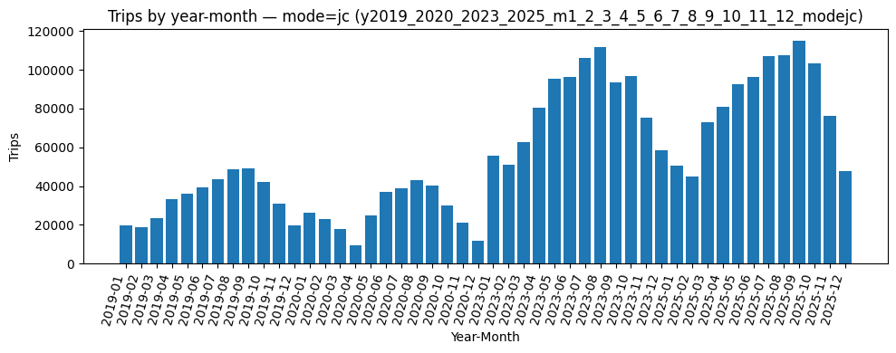

```python
# --- Trips by month (THIS RUN) ---
m = df_month.copy()

# Normalize month labels
if "month" in m.columns:
    m["month"] = pd.to_numeric(m["month"], errors="coerce").astype("Int64")
if "year" in m.columns:
    m["year"] = pd.to_numeric(m["year"], errors="coerce").astype("Int64")

display(m.sort_values([c for c in ["year", "month"] if c in m.columns]))

# If multiple years, show stacked-ish bars by year-month
if {"year", "month", "trips"}.issubset(m.columns):
    m2 = m.dropna(subset=["year","month"]).copy()
    m2["ym"] = m2["year"].astype(int).astype(str) + "-" + m2["month"].astype(int).astype(str).str.zfill(2)

    plt.figure(figsize=(10,4))
    plt.bar(m2["ym"], m2["trips"])
    plt.title(f"Trips by year-month — mode={mode} ({run_label})")
    plt.xlabel("Year-Month")
    plt.ylabel("Trips")
    plt.xticks(rotation=75, ha="right")
    plt.tight_layout()
    savefig("02_trips_by_year_month.png")
    plt.show()
else:
    print("Expected columns not present for trips-by-month plot. Have:", list(m.columns))
```

| year month | 2019 | 2020 | 2023 | 2025 |
| --- | --- | --- | --- | --- |
| 1 | 19676 | 26020 | 55811 | 50335 |
| 2 | 18564 | 22961 | 51001 | 45019 |
| 3 | 23604 | 17716 | 62802 | 72932 |
| 4 | 33050 | 9267 | 80379 | 81058 |
| 5 | 36123 | 25064 | 95486 | 92603 |
| 6 | 39422 | 36906 | 96434 | 96437 |
| 7 | 43741 | 38656 | 105977 | 106944 |
| 8 | 48706 | 43252 | 111469 | 107647 |
| 9 | 49240 | 40368 | 93670 | 115120 |
| 10 | 42247 | 30078 | 96975 | 103141 |
| 11 | 30794 | 21269 | 75237 | 75995 |
| 12 | 19728 | 11692 | 58285 | 47710 |

```
Saved: /home/hamzeh-khanpour/Desktop/CITIBIK-main/reports/y2019_2020_2023_2025_m1_2_3_4_5_6_7_8_9_10_11_12_modejc/figures/03_month_by_year_lines.png
```

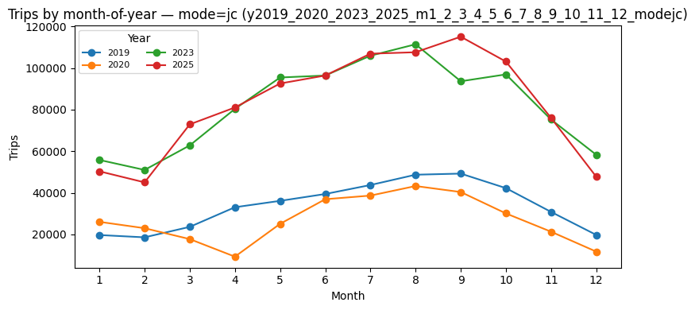

```python
# --- Month-of-year seasonality (line chart per year) ---
m = df_month.copy()
if not {"year","month","trips"}.issubset(m.columns):
    print("Month table missing required columns:", list(m.columns))
else:
    m["year"]  = pd.to_numeric(m["year"], errors="coerce").astype("Int64")
    m["month"] = pd.to_numeric(m["month"], errors="coerce").astype("Int64")
    m = m.dropna(subset=["year","month"]).copy()
    m = m.sort_values(["year","month"])

    pivot = m.pivot_table(index="month", columns="year", values="trips", aggfunc="sum").sort_index()
    display(pivot)

    plt.figure(figsize=(8,4))
    for y in pivot.columns:
        plt.plot(pivot.index.astype(int), pivot[y], marker="o", label=str(int(y)))
    plt.title(f"Trips by month-of-year — mode={mode} ({run_label})")
    plt.xlabel("Month")
    plt.ylabel("Trips")
    plt.xticks(range(1,13))
    plt.legend(title="Year", ncol=2, fontsize=8)
    plt.tight_layout()
    savefig("03_month_by_year_lines.png")
    plt.show()
```

## 3) Day-of-week patterns (comparison)

```
Years present in df_dow: [2019, 2020, 2023, 2025]

Trips by day-of-week (pivot):
```

| dow | year dow_name | 2019 | 2020 | 2023 | 2025 |
| --- | --- | --- | --- | --- | --- |
| 0 | Monday | 59485 | 41413 | 133238 | 134037 |
| 1 | Tuesday | 64849 | 44713 | 145219 | 147700 |
| 2 | Wednesday | 64313 | 45229 | 151916 | 147380 |
| 3 | Thursday | 60689 | 43774 | 150571 | 150079 |
| 4 | Friday | 63596 | 43950 | 145959 | 156534 |
| 5 | Saturday | 49782 | 54285 | 132008 | 140097 |
| 6 | Sunday | 42181 | 49885 | 124615 | 119114 |

```
Share of trips within each year (%):
```

| dow | year dow_name | 2019 | 2020 | 2023 | 2025 |
| --- | --- | --- | --- | --- | --- |
| 0 | Monday | 14.69 | 12.81 | 13.55 | 13.47 |
| 1 | Tuesday | 16.02 | 13.83 | 14.77 | 14.85 |
| 2 | Wednesday | 15.88 | 13.99 | 15.45 | 14.81 |
| 3 | Thursday | 14.99 | 13.54 | 15.31 | 15.08 |
| 4 | Friday | 15.71 | 13.60 | 14.84 | 15.73 |
| 5 | Saturday | 12.30 | 16.79 | 13.42 | 14.08 |
| 6 | Sunday | 10.42 | 15.43 | 12.67 | 11.97 |

```
Saved: /home/hamzeh-khanpour/Desktop/CITIBIK-main/reports/y2019_2020_2023_2025_m1_2_3_4_5_6_7_8_9_10_11_12_modejc/figures/10_dow_year_comparison_abs.png
```

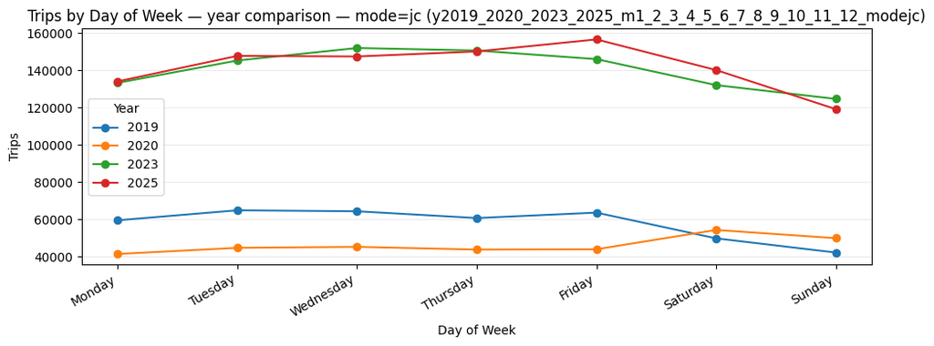

```
Saved: /home/hamzeh-khanpour/Desktop/CITIBIK-main/reports/y2019_2020_2023_2025_m1_2_3_4_5_6_7_8_9_10_11_12_modejc/figures/10_dow_year_comparison_pct.png
```

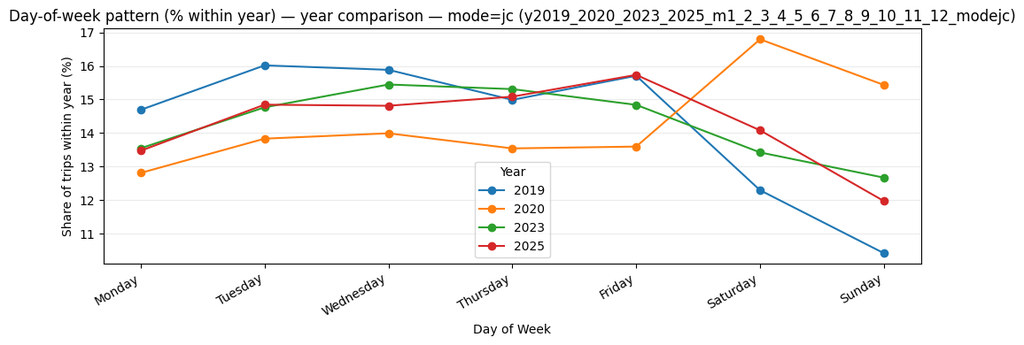

```
Saved: /home/hamzeh-khanpour/Desktop/CITIBIK-main/reports/y2019_2020_2023_2025_m1_2_3_4_5_6_7_8_9_10_11_12_modejc/figures/10_weekday_weekend_year_comparison_pct.png
```

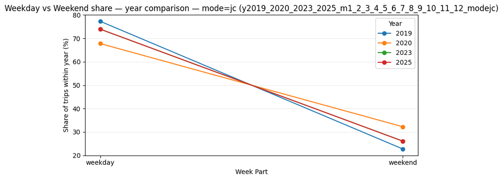

```python
# --- Day-of-week patterns (comparison across years; robust even if dow_name missing) ---

import numpy as np
import pandas as pd
import matplotlib.pyplot as plt

if df_dow is None or len(df_dow) == 0:
    print("df_dow is None/empty; skipping DOW comparison.")
else:
    d = df_dow.copy()

    # ---- Required columns ----
    req = {"dow", "trips"}
    missing = [c for c in req if c not in d.columns]
    if missing:
        raise KeyError(f"df_dow missing required columns {missing}. Have: {list(d.columns)}")

    # Ensure year exists for "comparison"
    if "year" not in d.columns:
        print("df_dow has no 'year' column; cannot do year comparison.")
        display(d.head(20))
    else:
        # ---- Clean types ----
        d["dow"] = pd.to_numeric(d["dow"], errors="coerce")
        d["trips"] = pd.to_numeric(d["trips"], errors="coerce").fillna(0)
        d["year"] = pd.to_numeric(d["year"], errors="coerce")
        d = d.dropna(subset=["dow", "year"]).copy()
        d["dow"] = d["dow"].astype(int)
        d["year"] = d["year"].astype(int)

        # ---- Add dow_name if missing (deterministic mapping) ----
        if "dow_name" not in d.columns:
            dow_map = {
                0: "Monday", 1: "Tuesday", 2: "Wednesday", 3: "Thursday",
                4: "Friday", 5: "Saturday", 6: "Sunday",
            }
            d["dow_name"] = d["dow"].map(dow_map).fillna(d["dow"].astype(str))

        # ---- Add week_part if missing ----
        if "week_part" not in d.columns:
            d["week_part"] = np.where(d["dow"] >= 5, "weekend", "weekday")

        years = sorted(d["year"].unique().tolist())
        print("Years present in df_dow:", years)

        # ---- TABLE 1: pivot (dow_name x year) ----
        pivot = (
            d.pivot_table(index=["dow", "dow_name"], columns="year", values="trips", aggfunc="sum")
             .sort_index(level=0)
        )
        print("\nTrips by day-of-week (pivot):")
        display(pivot)

        # ---- TABLE 2: shares within each year (percent of yearly total) ----
        shares = (
            d.groupby(["year", "dow", "dow_name"], as_index=False)["trips"]
             .sum()
             .sort_values(["year", "dow"])
        )
        shares["pct_of_year"] = shares["trips"] / shares.groupby("year")["trips"].transform("sum") * 100.0
        share_pivot = (
            shares.pivot_table(index=["dow", "dow_name"], columns="year", values="pct_of_year", aggfunc="first")
                  .sort_index(level=0)
        )
        print("\nShare of trips within each year (%):")
        display(share_pivot.round(2))

        # ---- PLOT 1: absolute trips per DOW for each year ----
        plt.figure(figsize=(10, 4))
        x_labels = [f"{n}" for n in pivot.index.get_level_values("dow_name")]
        x = np.arange(len(x_labels))

        for yy in years:
            if yy in pivot.columns:
                plt.plot(x, pivot[yy].values, marker="o", label=str(yy))

        plt.xticks(x, x_labels, rotation=30, ha="right")
        plt.xlabel("Day of Week")
        plt.ylabel("Trips")
        plt.title(f"Trips by Day of Week — year comparison — mode={mode} ({run_label})")
        plt.grid(alpha=0.25, axis="y")
        plt.legend(title="Year")
        plt.tight_layout()
        savefig("10_dow_year_comparison_abs.png")
        plt.show()

        # ---- PLOT 2: % share per DOW for each year (better for pattern comparison) ----
        plt.figure(figsize=(10, 4))
        for yy in years:
            if yy in share_pivot.columns:
                plt.plot(x, share_pivot[yy].values, marker="o", label=str(yy))

        plt.xticks(x, x_labels, rotation=30, ha="right")
        plt.xlabel("Day of Week")
        plt.ylabel("Share of trips within year (%)")
        plt.title(f"Day-of-week pattern (% within year) — year comparison — mode={mode} ({run_label})")
        plt.grid(alpha=0.25, axis="y")
        plt.legend(title="Year")
        plt.tight_layout()
        savefig("10_dow_year_comparison_pct.png")
        plt.show()

        # ---- OPTIONAL: weekday vs weekend bar per year ----
        wp = (
            d.groupby(["year", "week_part"], as_index=False)["trips"]
             .sum()
             .sort_values(["year", "week_part"])
        )
        wp["pct"] = wp["trips"] / wp.groupby("year")["trips"].transform("sum") * 100.0

        plt.figure(figsize=(8, 4))
        # make consistent order
        order = ["weekday", "weekend"]
        for yy in years:
            sub = wp[wp["year"] == yy].copy()
            sub["week_part"] = pd.Categorical(sub["week_part"], categories=order, ordered=True)
            sub = sub.sort_values("week_part")
            plt.plot(sub["week_part"].astype(str), sub["pct"].values, marker="o", label=str(yy))

        plt.xlabel("Week Part")
        plt.ylabel("Share of trips within year (%)")
        plt.title(f"Weekday vs Weekend share — year comparison — mode={mode} ({run_label})")
        plt.grid(alpha=0.25, axis="y")
        plt.legend(title="Year")
        plt.tight_layout()
        savefig("10_weekday_weekend_year_comparison_pct.png")
        plt.show()
```

## 4) Hour-of-day patterns (comparison)

```
Years present in df_hour: [2019, 2020, 2023, 2025]

Sample rows per year (first 8 hours for each year):
```

|  | mode | year | hour | week_part | trips |
| --- | --- | --- | --- | --- | --- |
| 0 | jc | 2019 | 0 | weekday | 1443 |
| 24 | jc | 2019 | 0 | weekend | 1335 |
| 1 | jc | 2019 | 1 | weekday | 767 |
| 25 | jc | 2019 | 1 | weekend | 839 |
| 2 | jc | 2019 | 2 | weekday | 397 |
| 26 | jc | 2019 | 2 | weekend | 546 |
| 3 | jc | 2019 | 3 | weekday | 297 |
| 27 | jc | 2019 | 3 | weekend | 347 |
| 48 | jc | 2020 | 0 | weekday | 1821 |
| 72 | jc | 2020 | 0 | weekend | 1322 |
| 49 | jc | 2020 | 1 | weekday | 878 |
| 73 | jc | 2020 | 1 | weekend | 802 |
| 50 | jc | 2020 | 2 | weekday | 410 |
| 74 | jc | 2020 | 2 | weekend | 457 |
| 51 | jc | 2020 | 3 | weekday | 279 |
| 75 | jc | 2020 | 3 | weekend | 251 |
| 96 | jc | 2023 | 0 | weekday | 5378 |
| 120 | jc | 2023 | 0 | weekend | 5973 |
| 97 | jc | 2023 | 1 | weekday | 2753 |
| 121 | jc | 2023 | 1 | weekend | 4445 |
| 98 | jc | 2023 | 2 | weekday | 1449 |
| 122 | jc | 2023 | 2 | weekend | 2942 |
| 99 | jc | 2023 | 3 | weekday | 859 |
| 123 | jc | 2023 | 3 | weekend | 1544 |
| 144 | jc | 2025 | 0 | weekday | 5335 |
| 168 | jc | 2025 | 0 | weekend | 5863 |
| 145 | jc | 2025 | 1 | weekday | 2572 |
| 169 | jc | 2025 | 1 | weekend | 4082 |
| 146 | jc | 2025 | 2 | weekday | 1399 |
| 170 | jc | 2025 | 2 | weekend | 2860 |
| 147 | jc | 2025 | 3 | weekday | 807 |
| 171 | jc | 2025 | 3 | weekend | 1641 |

```
Saved: /home/hamzeh-khanpour/Desktop/CITIBIK-main/reports/y2019_2020_2023_2025_m1_2_3_4_5_6_7_8_9_10_11_12_modejc/figures/05_trips_by_hour_year_comparison.png
```

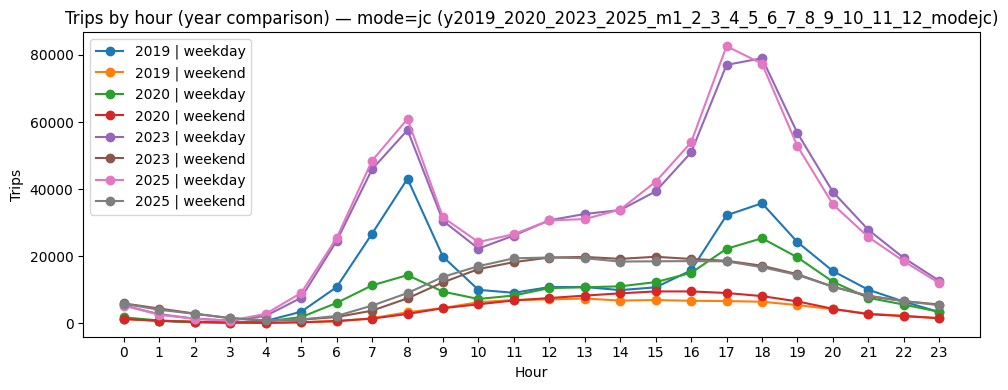

```python
# --- Trips by hour: compare years (table + plot) ---

import pandas as pd
import matplotlib.pyplot as plt

h = df_hour.copy()

hour_col = "hour" if "hour" in h.columns else None
trips_col = "trips" if "trips" in h.columns else None
year_col  = "year" if "year" in h.columns else None

part_col = None
for c in ["week_part", "segment", "is_weekend"]:
    if c in h.columns:
        part_col = c
        break

if not (hour_col and trips_col and year_col):
    print("Hour table missing required columns. Have:", list(h.columns))
else:
    # Clean
    h[hour_col] = pd.to_numeric(h[hour_col], errors="coerce")
    h[trips_col] = pd.to_numeric(h[trips_col], errors="coerce")
    h[year_col] = pd.to_numeric(h[year_col], errors="coerce")
    h = h.dropna(subset=[hour_col, trips_col, year_col]).copy()
    h[hour_col] = h[hour_col].astype(int)
    h[year_col] = h[year_col].astype(int)

    years = sorted(h[year_col].unique().tolist())
    print("Years present in df_hour:", years)

    # ---- TABLES ----
    print("\nSample rows per year (first 8 hours for each year):")
    display(
        h.sort_values([year_col, hour_col])
         .groupby(year_col, as_index=False)
         .head(8)
    )

# #    if part_col:
# #        print(f"\nPivot table: trips by hour × year × {part_col}")
#         pivot = (
#             h.pivot_table(index=[hour_col, part_col], columns=year_col, values=trips_col, aggfunc="sum")
#              .sort_index()
#         )
#         display(pivot)
#     else:
#         print("\nPivot table: trips by hour × year")
#         pivot = (
#             h.pivot_table(index=hour_col, columns=year_col, values=trips_col, aggfunc="sum")
#              .sort_index()
#         )
#         display(pivot)

    # ---- PLOT ----
    plt.figure(figsize=(10,4))
    if part_col:
        for (yy, seg), sub in h.groupby([year_col, part_col]):
            sub = sub.sort_values(hour_col)
            plt.plot(sub[hour_col], sub[trips_col], marker="o", label=f"{yy} | {seg}")
    else:
        for yy, sub in h.groupby(year_col):
            sub = sub.sort_values(hour_col)
            plt.plot(sub[hour_col], sub[trips_col], marker="o", label=str(yy))

    plt.title(f"Trips by hour (year comparison) — mode={mode} ({run_label})")
    plt.xlabel("Hour")
    plt.ylabel("Trips")
    plt.xticks(range(0,24,1))
    plt.legend()
    plt.tight_layout()
    savefig("05_trips_by_hour_year_comparison.png")
    plt.show()
```